# Exercise 1

Marie Gleichauf, Chelsea Matthews, Hope Knopf

8/8/2018

# Exercise 1

## Probaility Practice

### Part A

We need P(yes|truthful clickers) WE know: P(yes) = .65 P(no) = .35 P(random clickers) = 0.3 P(truthful clikers) = 1-P(random clickers) = 1-0.3 = 0.7 P(yes|random clicker) = P(no|random clicker) = 0.5

P(Y) = P(Y|truthfull clickers) * P(truthful clickers) + P(Y|random clickers)*P(random clickers)

.65 = P(yes|truthful clickers)*0.7 + 0.5(0.3) P(yes|truthful clickers) = ((0.5)(0.3)-.65)/-0.7 P(yes|truthful clickers) = 0.7142857

About 71% of the truthful clickers answered yes.

### Part B

D = someone has disease H = someone does not have disease (healthy) P = positive test results N = negative test results

we need P(D|P) we have: P(D) = 0.000025 P(H) = 1-P(D) = 1-0.000025 = 0.999975 P(P|D) = .993 P(N|H) = 0.9999 P(P|H) = 1-0.9999=.0001

P(P) = P(P|D)P(D) + P(P|H)P(H) =(.993*0.000025) + (.0001*0.999975) P(P) = 0.0001248225

Using Bayes P(D|P) = (P(D)*P(P|D))/P(P) = (0.000025*.993)/0.0001248225 P(D|P) = 0.1988824

The probability that a person has the disease given that they test positive is about 20%. The low accuracy of this test could present numerous problems and lead to expensive further testing and treatments to people who don’t actually have the disease.

## Exploratory Analysis: Green Buildings

```r
library(mosaic)

green = read.csv('~/Documents/UT/Summer Classes/Intro to Predictive Modeling/Part 2/HW 1/greenbuildings.csv')

attach(green)
summary(green)
```

```
##  CS_PropertyID        cluster            size            empl_gr
##  Min.   :      1   Min.   :   1.0   Min.   :   1624   Min.   :-24.950
##  1st Qu.: 157452   1st Qu.: 272.0   1st Qu.:  50891   1st Qu.:  1.740
##  Median : 313253   Median : 476.0   Median : 128838   Median :  1.970
##  Mean   : 453003   Mean   : 588.6   Mean   : 234638   Mean   :  3.207
##  3rd Qu.: 441188   3rd Qu.:1044.0   3rd Qu.: 294212   3rd Qu.:  2.380
##  Max.   :6208103   Max.   :1230.0   Max.   :3781045   Max.   : 67.780
##                                                       NA's   :74
##       Rent         leasing_rate       stories            age
##  Min.   :  2.98   Min.   :  0.00   Min.   :  1.00   Min.   :  0.00
##  1st Qu.: 19.50   1st Qu.: 77.85   1st Qu.:  4.00   1st Qu.: 23.00
##  Median : 25.16   Median : 89.53   Median : 10.00   Median : 34.00
##  Mean   : 28.42   Mean   : 82.61   Mean   : 13.58   Mean   : 47.24
##  3rd Qu.: 34.18   3rd Qu.: 96.44   3rd Qu.: 19.00   3rd Qu.: 79.00
##  Max.   :250.00   Max.   :100.00   Max.   :110.00   Max.   :187.00
##
##    renovated         class_a          class_b            LEED
##  Min.   :0.0000   Min.   :0.0000   Min.   :0.0000   Min.   :0.000000
##  1st Qu.:0.0000   1st Qu.:0.0000   1st Qu.:0.0000   1st Qu.:0.000000
##  Median :0.0000   Median :0.0000   Median :0.0000   Median :0.000000
##  Mean   :0.3795   Mean   :0.3999   Mean   :0.4595   Mean   :0.006841
##  3rd Qu.:1.0000   3rd Qu.:1.0000   3rd Qu.:1.0000   3rd Qu.:0.000000
##  Max.   :1.0000   Max.   :1.0000   Max.   :1.0000   Max.   :1.000000
##
##    Energystar       green_rating          net            amenities
##  Min.   :0.00000   Min.   :0.00000   Min.   :0.00000   Min.   :0.0000
##  1st Qu.:0.00000   1st Qu.:0.00000   1st Qu.:0.00000   1st Qu.:0.0000
##  Median :0.00000   Median :0.00000   Median :0.00000   Median :1.0000
##  Mean   :0.08082   Mean   :0.08677   Mean   :0.03471   Mean   :0.5266
##  3rd Qu.:0.00000   3rd Qu.:0.00000   3rd Qu.:0.00000   3rd Qu.:1.0000
##  Max.   :1.00000   Max.   :1.00000   Max.   :1.00000   Max.   :1.0000
##
##   cd_total_07     hd_total07    total_dd_07   Precipitation
##  Min.   :  39   Min.   :   0   Min.   :2103   Min.   :10.46
##  1st Qu.: 684   1st Qu.:1419   1st Qu.:2869   1st Qu.:22.71
##  Median : 966   Median :2739   Median :4979   Median :23.16
##  Mean   :1229   Mean   :3432   Mean   :4661   Mean   :31.08
##  3rd Qu.:1620   3rd Qu.:4796   3rd Qu.:6413   3rd Qu.:43.89
##  Max.   :5240   Max.   :7200   Max.   :8244   Max.   :58.02
##
##    Gas_Costs        Electricity_Costs  cluster_rent
##  Min.   :0.009487   Min.   :0.01780   Min.   : 9.00
##  1st Qu.:0.010296   1st Qu.:0.02330   1st Qu.:20.00
##  Median :0.010296   Median :0.03274   Median :25.14
##  Mean   :0.011336   Mean   :0.03096   Mean   :27.50
##  3rd Qu.:0.011816   3rd Qu.:0.03781   3rd Qu.:34.00
##  Max.   :0.028914   Max.   :0.06280   Max.   :71.44
##
```

```r
green=green[green$leasing_rate>10,] #remove low occupancy
```

```r
rent_green = lm(Rent~., data = green)
summary(rent_green)
```

```
##
## Call:
## lm(formula = Rent ~ ., data = green)
##
## Residuals:
##     Min      1Q  Median      3Q     Max
## -53.853  -3.583  -0.540   2.472 173.915
##
## Coefficients: (1 not defined because of singularities)
##                     Estimate Std. Error t value Pr(>|t|)
## (Intercept)       -8.527e+00  1.096e+00  -7.782 8.06e-15 ***
## CS_PropertyID      3.675e-07  1.724e-07   2.132 0.033047 *
## cluster            7.322e-04  2.897e-04   2.527 0.011511 *
## size               6.744e-06  6.628e-07  10.176  < 2e-16 ***
## empl_gr            6.690e-02  1.746e-02   3.831 0.000128 ***
## leasing_rate       1.255e-02  6.866e-03   1.828 0.067648 .
## stories           -3.376e-02  1.635e-02  -2.065 0.038956 *
## age               -1.162e-02  4.839e-03  -2.401 0.016360 *
## renovated         -1.745e-01  2.650e-01  -0.658 0.510326
## class_a            2.943e+00  4.506e-01   6.531 6.95e-11 ***
## class_b            1.258e+00  3.557e-01   3.536 0.000408 ***
## LEED               1.881e+00  3.607e+00   0.522 0.601919
## Energystar        -2.171e-01  3.844e+00  -0.056 0.954955
## green_rating       6.977e-01  3.865e+00   0.181 0.856757
## net               -2.512e+00  5.989e-01  -4.195 2.76e-05 ***
## amenities          6.621e-01  2.559e-01   2.587 0.009692 **
## cd_total_07       -1.681e-04  1.502e-04  -1.119 0.262972
## hd_total07         5.047e-04  9.141e-05   5.521 3.48e-08 ***
## total_dd_07               NA         NA      NA       NA
## Precipitation      4.822e-02  1.653e-02   2.918 0.003537 **
## Gas_Costs         -3.547e+02  8.066e+01  -4.397 1.11e-05 ***
## Electricity_Costs  1.839e+02  2.543e+01   7.232 5.23e-13 ***
## cluster_rent       1.012e+00  1.462e-02  69.244  < 2e-16 ***
## ---
## Signif. codes:  0 '***' 0.001 '**' 0.01 '*' 0.05 '.' 0.1 ' ' 1
##
## Residual standard error: 9.477 on 7584 degrees of freedom
##   (73 observations deleted due to missingness)
## Multiple R-squared:  0.6106, Adjusted R-squared:  0.6095
## F-statistic: 566.2 on 21 and 7584 DF,  p-value: < 2.2e-16
```

Running a linear regression gave us an indication of which variables could affect rent prices.

```r
#take subset of green and not green buildings
green_building = subset(green, green_rating==1)
dim(green_building)
```

```
## [1] 684  23
```

```r
non_green_building=subset(green, green_rating!=1)
dim(non_green_building)
```

```
## [1] 6995   23
```

There are many fewer green buildings in the data set than there are non green buildings, which could potentially skew our findings. Better recommendations could be made from a larger dataset or more balanced observations.

```r
#amenities
green_building_amenities = subset(green_building, amenities==1)
median(green_building_amenities$Rent)
```

```
## [1] 27.775
```

```r
nrow(green_building_amenities)/nrow(green_building)
```

```
## [1] 0.7280702
```

```r
non_green_building_amenities = subset(non_green_building, amenities==1)
median(non_green_building_amenities$Rent)
```

```
## [1] 25
```

```r
nrow(non_green_building_amenities)/nrow(non_green_building)
```

```
## [1] 0.519371
```

The median rent is around $2.78 more for green buildings with amenities as compared to non green buildings with amenities. Further, 72.8% of green buildings have amenities, whereas only 51% of non green buildings have amenities. Amenities is therefore a variable that could have affected the higher rent found for green buildings.

```r
#age
green_building_age = subset(green_building, age<10)
median(green_building_age$Rent)
```

```
## [1] 26.75
```

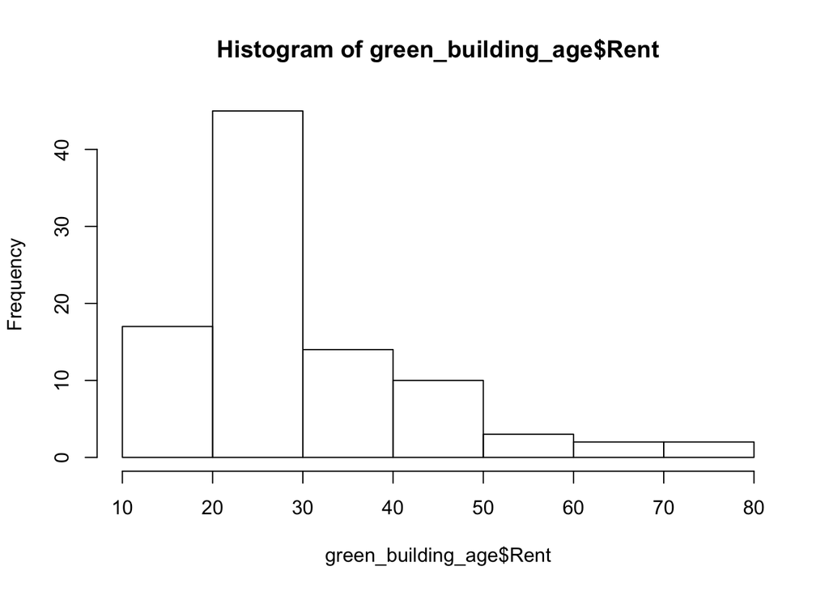

```r
hist(green_building_age$Rent)
```

```r
non_green_building_age = subset(non_green_building, age<10)
median(non_green_building_age$Rent)
```

```
## [1] 29
```

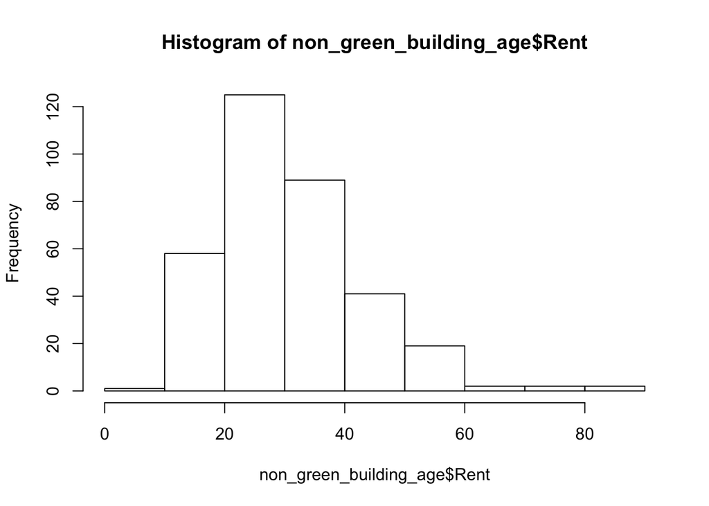

```r
hist(non_green_building_age$Rent)
```

Surprisingly, the median rent for green buildings under 10 years old is only $26.75 while the median rent for non green buildings under 10 years old is higher at $29. This contradicts the the excel guru’s conclusions that green buildings tend to have higher rent and is an interesting variable to consider since in this case, the results of examining the difference between green and non green buildings while holding this variable constant seems counterintuitive. You would anticipate that newer green buildngs would mean higher median rents than newer non green buildings, but for those under 10 years old the opposite was the case. The histograms of the rent values also provide evidence that a greater number of non green buildings under 10 years old have higher rent values overall.

```r
 #class
class_a = subset(green, class_a==1)
class_a_green = subset(green_building,class_a==1)
class_a_non_green = subset(non_green_building,class_a != 1)

class_b = subset(green, class_b==1)
class_b_green = subset(green_building,class_b==1)
class_b_non_green = subset(non_green_building,class_b !=1 )

nrow(class_a_green)/nrow(green_building)
```

```
## [1] 0.7982456
```

```r
nrow(class_a_non_green)/nrow(non_green_building)
```

```
## [1] 0.6298785
```

```r
median(class_a$Rent)
```

```
## [1] 28.2
```

```r
median(class_b$Rent)
```

```
## [1] 24
```

```r
median(class_a_green$Rent)
```

```
## [1] 28.44
```

```r
median(class_a_non_green$Rent)
```

```
## [1] 23.65
```

```r
median(class_b_green$Rent)
```

```
## [1] 25.2
```

```r
median(class_b_non_green$Rent)
```

```
## [1] 25.85
```

### Final Conclusions

From our analysis, we cannot conclusively say that green buildings will generate higher rent values because various variables such as amenities, age, and class of materials also affect the rent values in numeruous and different ways. We therefore believe that although the excel guru performed some valid analysis, other potentially interacting variables make it difficult to accurately predict the projected revenue from rent and make it difficult to know if greater rent prices are due to a building being green or not or due to other characteristic variables. Further analysis into potentially interacting variables, both those explored here and others such as the attributes of other buildings in the cluster Austin resides in, would need to be considered before recommending with any certainty that building the green building would be the best and most profitable option.

## Bootstrapping

```r
library(mosaic)
library(quantmod)
library(foreach)
set.seed(11)
mystocks = c("SPY","TLT","LQD","EEM","VNQ")
myprices = getSymbols(mystocks, from = "2007-01-01")

for(ticker in mystocks) {
    expr = paste0(ticker, "a = adjustOHLC(", ticker, ")")
    eval(parse(text=expr))
}


all_returns =cbind( ClCl(SPYa), ClCl(TLTa),ClCl(LQDa),ClCl(EEMa),ClCl(VNQa))
head(all_returns)
```

```
##                ClCl.SPYa    ClCl.TLTa     ClCl.LQDa    ClCl.EEMa
## 2007-01-03            NA           NA            NA           NA
## 2007-01-04  0.0021221123  0.006063328  0.0075152938 -0.013809353
## 2007-01-05 -0.0079763183 -0.004352668 -0.0006526807 -0.029238205
## 2007-01-08  0.0046250821  0.001793566 -0.0002798843  0.007257535
## 2007-01-09 -0.0008498831  0.000000000  0.0001866169 -0.022336235
## 2007-01-10  0.0033315799 -0.004475797 -0.0013063264 -0.002303160
##               ClCl.VNQa
## 2007-01-03           NA
## 2007-01-04  0.001296655
## 2007-01-05 -0.018518518
## 2007-01-08  0.001451392
## 2007-01-09  0.012648208
## 2007-01-10  0.012880523
```

```r
all_returns=as.matrix(na.omit(all_returns))
```

```r
cor(all_returns)
```

```
##            ClCl.SPYa  ClCl.TLTa  ClCl.LQDa   ClCl.EEMa   ClCl.VNQa
## ClCl.SPYa  1.0000000 -0.4362039 0.10138629  0.40655662  0.76825670
## ClCl.TLTa -0.4362039  1.0000000 0.43231008 -0.16740809 -0.25342832
## ClCl.LQDa  0.1013863  0.4323101 1.00000000  0.08796421  0.07150396
## ClCl.EEMa  0.4065566 -0.1674081 0.08796421  1.00000000  0.29231339
## ClCl.VNQa  0.7682567 -0.2534283 0.07150396  0.29231339  1.00000000
```

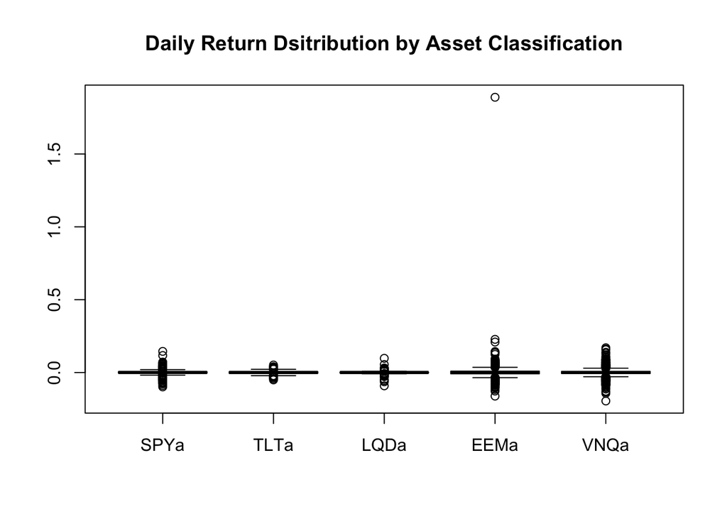

```r
boxplot(all_returns,main = "Daily Return Dsitribution by Asset Classification",names =c( "SPYa","TLTa","LQDa","EEMa","VNQa"))
```

```r
summary(all_returns)
```

```
##    ClCl.SPYa            ClCl.TLTa            ClCl.LQDa
##  Min.   :-0.0984477   Min.   :-0.0504495   Min.   :-0.0911111
##  1st Qu.:-0.0038636   1st Qu.:-0.0052394   1st Qu.:-0.0019182
##  Median : 0.0006589   Median : 0.0005553   Median : 0.0004104
##  Mean   : 0.0003989   Mean   : 0.0002710   Mean   : 0.0002066
##  3rd Qu.: 0.0056254   3rd Qu.: 0.0056656   3rd Qu.: 0.0024758
##  Max.   : 0.1451977   Max.   : 0.0516616   Max.   : 0.0976772
##    ClCl.EEMa            ClCl.VNQa
##  Min.   :-0.1616620   Min.   :-0.1951372
##  1st Qu.:-0.0085267   1st Qu.:-0.0069231
##  Median : 0.0008056   Median : 0.0006617
##  Mean   : 0.0009985   Mean   : 0.0004095
##  3rd Qu.: 0.0092223   3rd Qu.: 0.0077793
##  Max.   : 1.8891250   Max.   : 0.1700654
```

Looking at the boxplot, it is noticeable that the safest investments are US domestic equities (SPY), investment grade corporate bonds(LQD) and U.S. Treaury bonds (TLT). They have the smallest Inter-quartile ranges (IQR) according to the boxplots. On the other hand, emerging market equities (EEM) and real estate (VNQ) are the riskier investments. They have wider IQRs. This is to be expected becuase emerging markets and real estate are notoriously the most volatile. Becuase of the risk/return tradeoff, riskier investments have higher potential returns. Investors have to be willing to accept a higher risk of losses, in order to get higher potential returns.

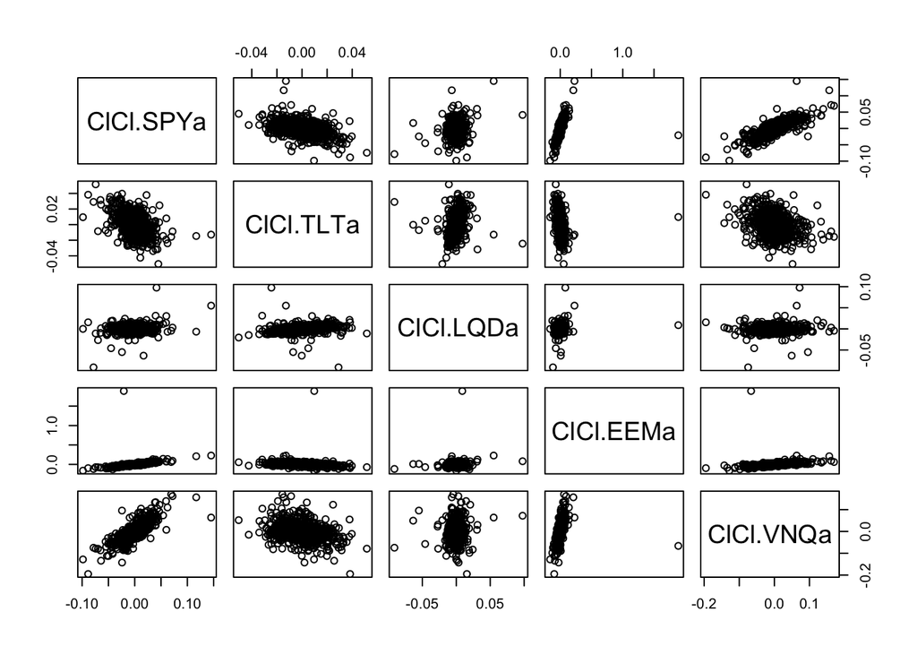

```r
pairs(all_returns)
```

SPY and TLT seem to be negatively correlated. SPY has a positive correlation with VNQ. VNQ also has a positive correlation with EEM. LQD has a positive correlation with TLT. Becuase of the negative correlation between SPY and TLT and because of their low variation, they will go in the safe portfolio. The negative correlation means that if one stock goes down, then the other is likely to go up. LQD also has low variation, so it will be the third allocation in the safe profile. EEM nad VNQ will so in the riskier portfolio because they have the most variation and are likely to move together, meaning if they go up, there is large potential profit. On the downside, there are large potential losses if they go down.

### Even Split

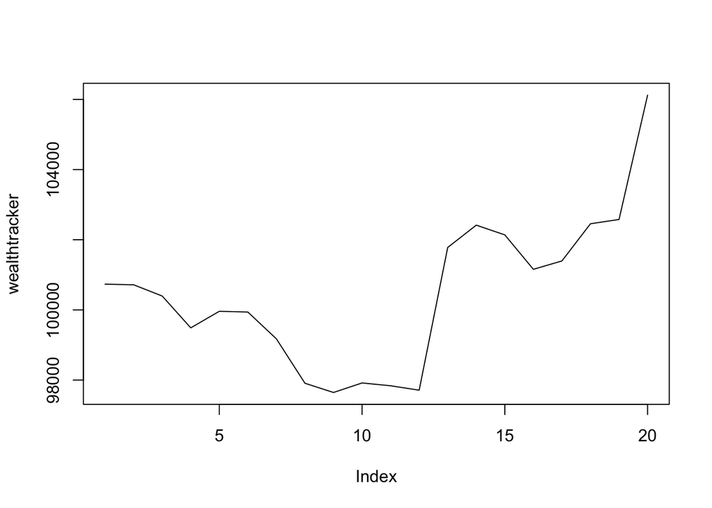

```r
#even split
set.seed(11)
return.today = resample(all_returns, 1, orig.ids=FALSE)
initial_wealth = 100000
sim1 = foreach(i=1:5000, .combine='rbind')%do% {
  total_wealth = initial_wealth
  my_weights = c(0.2,0.2,0.2,0.2,0.2)
  holdings = total_wealth*my_weights
  n_days = 20
  wealthtracker = rep(0,n_days)
  for(today in 1:n_days){
    holdings = total_wealth*my_weights
    return.today = resample(all_returns,1,orig.ids=FALSE)
    holdings = holdings+holdings*return.today #reallocating everyday
    total_wealth=sum(holdings)
    wealthtracker[today]=total_wealth
  }
  wealthtracker
}
plot(wealthtracker, type='l')
```

```r
head(sim1)
```

```
##               [,1]      [,2]      [,3]      [,4]      [,5]      [,6]
## result.1  98785.23  98976.64 100776.56 100060.40 100763.20  99015.92
## result.2 101075.51 101139.08 101008.27 101762.75 101523.62  99229.08
## result.3 100730.33 100833.26 101259.16 100678.99 100600.41 100635.62
## result.4  99812.01  98206.88  98165.84  97987.18  95225.81  95958.43
## result.5 100007.28 100743.76 102425.00 102045.42  99534.75  96982.69
## result.6  99996.56 100856.84  99238.80 100764.05 100025.64 100080.92
##              [,7]      [,8]      [,9]     [,10]     [,11]     [,12]
## result.1 97959.99  98217.83  97808.68  95456.26  94946.32  95905.43
## result.2 99527.30  99056.01 100495.51 100471.69 101506.39 101121.18
## result.3 99148.27  98635.93  98649.04  99023.72  99274.33  99840.48
## result.4 96327.83  94754.77  94434.42  95507.21  96051.87  96718.56
## result.5 96885.32  96831.84  96242.45  97120.46  96581.38  98337.75
## result.6 99790.05 100207.47  99486.93 100408.52 100222.60 100776.10
##              [,13]     [,14]     [,15]     [,16]     [,17]     [,18]
## result.1  96434.77  96906.83  97296.29  97112.39  97987.69 102035.16
## result.2  99848.00 100259.69 100130.22 100617.25 103269.73 103267.21
## result.3 100606.16 101370.23 101703.66 101569.64 101846.73  96598.48
## result.4  96521.23  97175.28  97524.60  97039.23  95295.39  95355.33
## result.5  98522.30  98663.94  98975.21  99724.68 102040.12 101958.68
## result.6 101045.73 100155.67 100664.97 100404.30 100639.28 100782.69
##              [,19]     [,20]
## result.1 102859.63 103946.18
## result.2 102526.96 103419.60
## result.3  96372.29  95755.85
## result.4  95620.32  96109.72
## result.5 102206.87 101520.28
## result.6 102037.80 104541.63
```

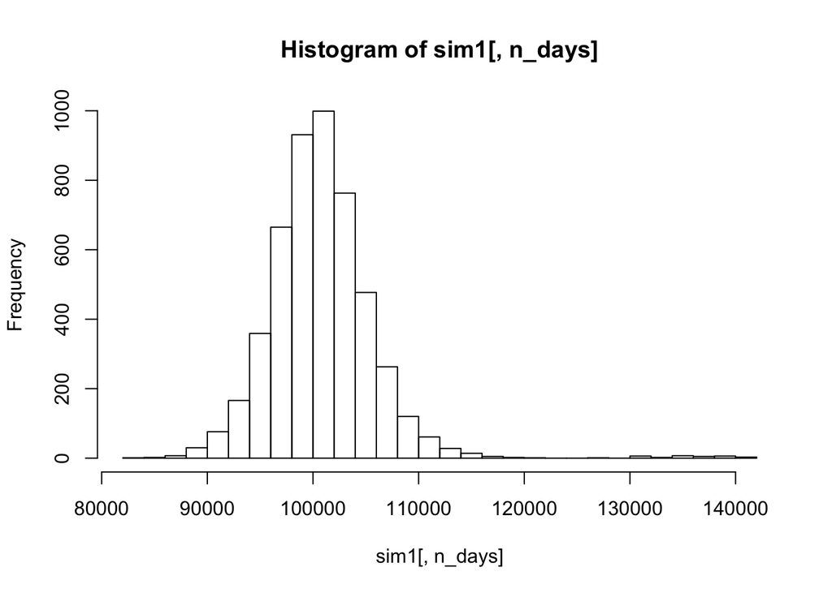

```r
hist(sim1[,n_days], 25)
```

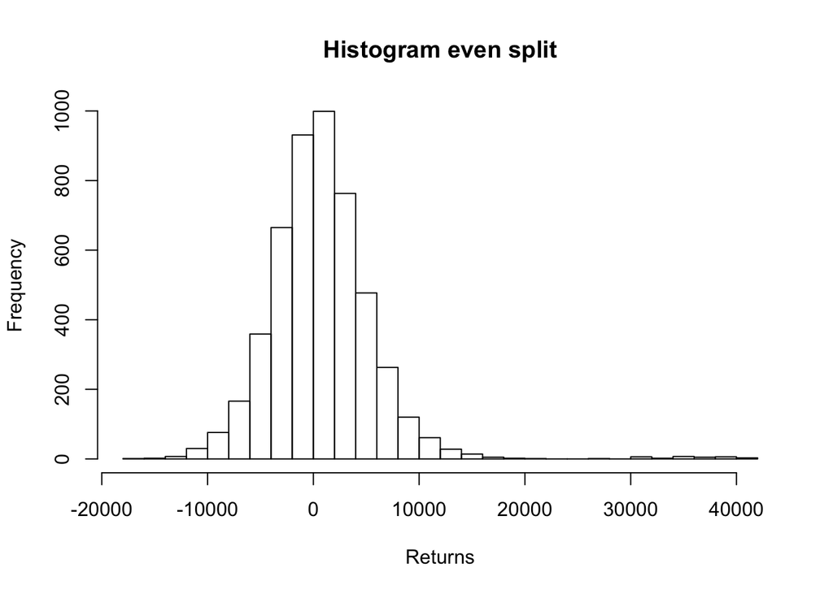

```r
hist(sim1[,n_days]- initial_wealth, main = paste('Histogram even split' ,sep= ' ' ), xlab="Returns" ,breaks=30)
abline(v=mean(sim1[,n_days]-1000),col='red',lwd=2)
```

```r
quantile(sim1[,n_days], 0.05) - initial_wealth
```

```
##        5%
## -6240.308
```

```r
mean(sim1[,n_days])
```

```
## [1] 100795.7
```

```r
total_wealth
```

```
## [1] 106120.2
```

Using the even split portfolio, the most that you will lose is $6,240.31 at a 95% confidence level. In this simulation, the total wealth at the end of the 20 days was $106,120.20 .

### Safer Portfolio

For the safer portfolio, we used only LQD, TLT, and SPY since they are the safest investment tolls.They have the least variation, meaning they have a lower chance of causes big losses. Bonds are less vulnerable to stock market fluctuation, allowing their prices to be more constant over-time. The trade-off is that there is a lower change of potential large earnings. From the boxplot we can see that LQD has the lowest variation, so it will be given the biggest weight, to be safer. SPY and TLT seem to be negatively correlated, so we will give them the same weighting of 0.25, in hopes that losses in one is balances from gains in the other.

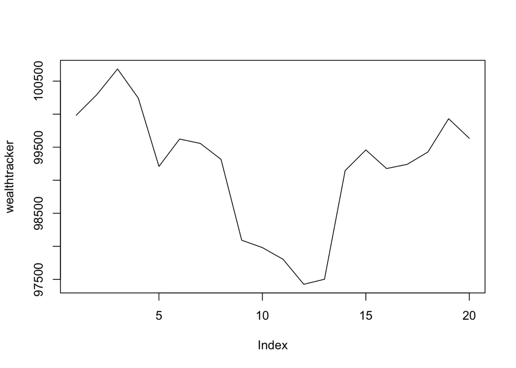

```r
#safer portfolio

set.seed(11)

initial_wealth = 100000
sim_safe = foreach(i=1:5000, .combine='rbind')%do% {
  total_wealth = initial_wealth
  my_weights = c(0.25,0.25,0.5, 0.0, 0.0)
  holdings = total_wealth*my_weights
  n_days = 20
  wealthtracker = rep(0,n_days)
  for(today in 1:n_days){
    holdings = total_wealth*my_weights
    return.today = resample(all_returns,1,orig.ids=FALSE)
    holdings = holdings+holdings*return.today #reallocating everyday
    total_wealth=sum(holdings)
    wealthtracker[today]=total_wealth
  }
  wealthtracker
}
plot(wealthtracker, type='l')
```

```r
head(sim_safe)
```

```
##              [,1]      [,2]      [,3]      [,4]      [,5]      [,6]
## result.1 100025.4  99684.41  99838.09 100001.32 100103.58 100368.13
## result.2 100424.9 100927.40 100934.80 100368.02 100642.71 100396.74
## result.3 100396.9 100382.97 100492.99 100621.30  99968.95  99922.87
## result.4 100176.0 100268.69 100392.97 100526.51 100000.75  99983.96
## result.5 100382.5 100526.01 100864.81 101664.95 101506.44 100963.02
## result.6 100016.9  99614.03  99929.79  99210.96 100101.47  99872.08
##               [,7]      [,8]      [,9]     [,10]     [,11]     [,12]
## result.1 100171.47 100138.93 100425.84 100442.80  99845.10  99937.63
## result.2  99896.40  99922.81 100015.03 100384.18 100310.34 100698.95
## result.3  99773.49  99503.85  99814.36  99725.67  99563.72  99759.50
## result.4 100137.41 100488.54 100377.96 100611.36 100890.43 101390.70
## result.5 100206.51 100053.83 100251.59 100146.43 100690.03 100700.33
## result.6 100077.98  99788.80 100086.24  99606.82 100229.08  99715.48
##             [,13]    [,14]     [,15]     [,16]     [,17]     [,18]
## result.1 100518.6 100993.0 100600.32 100889.89 100892.13 101658.12
## result.2 100775.8 100813.8 100989.70 101069.28 101312.72 102174.30
## result.3 100254.2 100338.0 101523.56 101705.20 101953.36 101781.66
## result.4 101104.4 101143.5 101556.96 101784.66 101994.73 100869.57
## result.5 100865.0 100985.2 101018.77 101332.10 101800.10 102637.60
## result.6 100140.3 100184.0  99369.52  99353.32  99350.03  99423.53
##              [,19]     [,20]
## result.1 101928.69 102195.98
## result.2 101733.15 101916.57
## result.3 100881.50 100588.50
## result.4 100876.96 101241.37
## result.5 102570.01 102122.87
## result.6  99227.45  99716.86
```

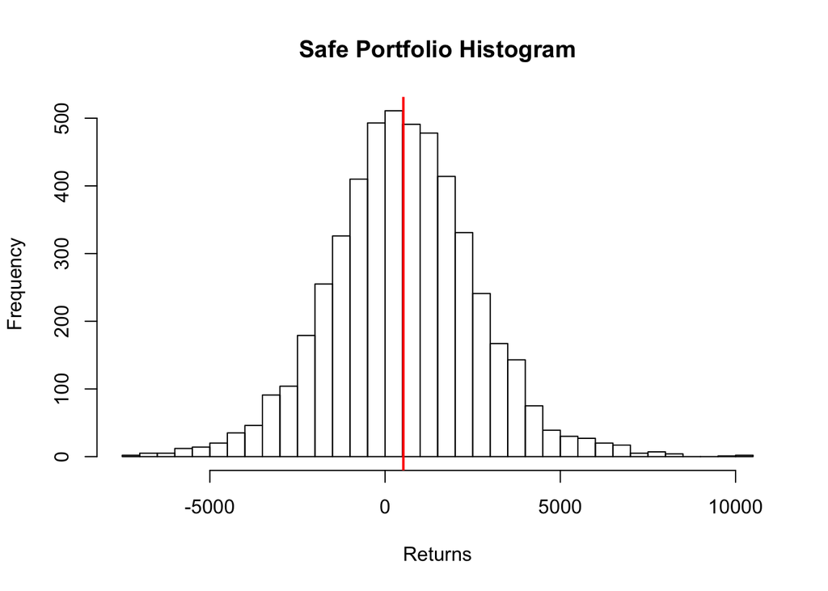

```r
hist(sim_safe[,n_days]- initial_wealth, main = "Safe Portfolio Histogram",xlab="Returns", breaks=30)
abline(v=mean(sim_safe[,n_days]- initial_wealth), col="red",lwd=2)
```

```r
mean(sim_safe[,n_days])
```

```
## [1] 100520.7
```

```r
quantile(sim_safe[,n_days], 0.05) - initial_wealth
```

```
##        5%
## -2849.684
```

```r
total_wealth
```

```
## [1] 99634.77
```

Using the safer portfolio, the most that you will lose is $2,849.68 at a 95% confidence level. In this simulation, the total wealth at the end of the 20 days was $99,634.77 .

### Agressive Portfolio

For the riskier portfolio, only EEM and VNQ were used becuase they were the two riskiest investments.Heavier weight (0.6) was given to EEM becuase it is the riskier investment and has the highest varaition. The two instruments are postively correlated.

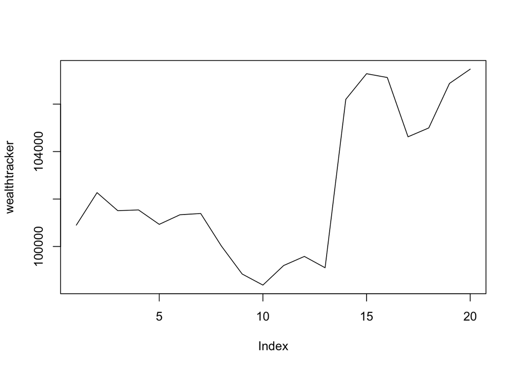

```r
#riskier portfolio
set.seed(11)
initial_wealth = 100000

sim_risk = foreach(i=1:5000, .combine='rbind')%do% {
  total_wealth = initial_wealth
  my_weights = c(0.0,0.0,0.0,0.6,0.4)
  holdings = total_wealth*my_weights
  n_days = 20
  wealthtracker = rep(0,n_days)
  for(today in 1:n_days){
    holdings = total_wealth*my_weights #re-allocating everyday
    return.today = resample(all_returns,1,orig.ids=FALSE)
    holdings = holdings+holdings*return.today
    total_wealth=sum(holdings)
    wealthtracker[today]=total_wealth
  }
  wealthtracker
}
plot(wealthtracker, type='l')
```

```r
head(sim_risk)
```

```
##               [,1]      [,2]      [,3]      [,4]      [,5]      [,6]
## result.1 100308.16  97805.44  98034.71 102056.02 100004.46 101243.85
## result.2 101810.89 104010.10 104376.49 104994.60 106572.85 106410.35
## result.3 101565.53 103388.53 103543.58 104409.93 104056.00 104067.32
## result.4  98333.14  97752.33  94477.78  94169.56  94390.24  88097.88
## result.5 100669.48 100345.44 101627.03 104093.21 103227.59  97715.64
## result.6  98428.66  98910.49 100339.63  97510.75  99855.52  98236.78
##               [,7]      [,8]      [,9]     [,10]     [,11]     [,12]
## result.1  97775.02  95326.86  95580.84  94676.43  89937.32  88411.45
## result.2 101500.89 102197.36 101298.20 104191.09 104202.45 106108.65
## result.3 104325.64 101096.17  99515.37  99566.13 100730.57 101012.60
## result.4  89456.31  89926.03  86727.54  85628.78  87596.57  88190.52
## result.5  92883.42  92870.09  92312.73  91001.78  92229.39  91044.78
## result.6  98060.77  97786.23  98463.17  97490.79  98595.70  99422.44
##              [,13]     [,14]     [,15]     [,16]     [,17]     [,18]
## result.1  89873.65  90658.85  92338.17  92839.09  92291.49  93235.23
## result.2 105299.39 102217.36 103021.28 102527.35 103269.76 108307.65
## result.3 101697.53 103268.87 103528.62 103932.37 103104.14 104258.98
## result.4  90034.30  89960.09  90951.27  91351.56  89806.58  87669.59
## result.5  94779.37  95117.53  95305.99  95724.25  96684.36 100642.48
## result.6 100131.13 100776.47  99827.87 101063.84 100424.19 100848.32
##              [,19]     [,20]
## result.1 102779.47 104538.61
## result.2 108814.70 106782.43
## result.3  93252.16  93058.30
## result.4  87978.42  87971.94
## result.5 100503.56 101532.29
## result.6 101481.53 103652.78
```

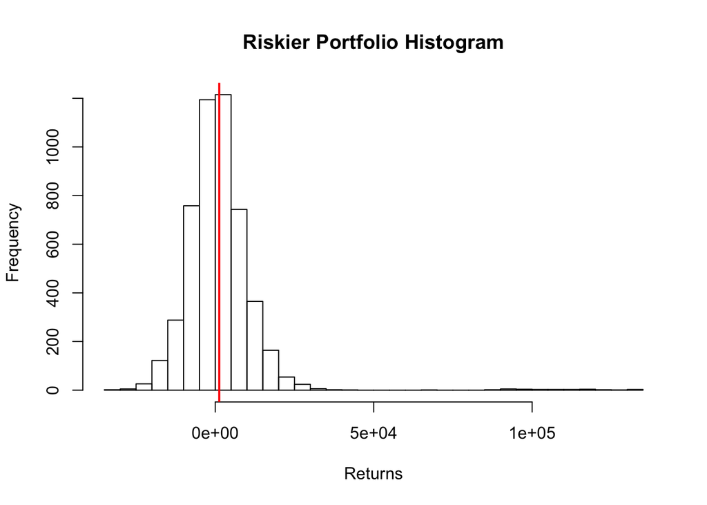

```r
hist(sim_risk[,n_days]- initial_wealth, main="Riskier Portfolio Histogram",xlab = "Returns", breaks=30)
abline(v=mean(sim_risk[,n_days]-100000),col="red",lwd=2)
```

```r
mean(sim_risk[,n_days])
```

```
## [1] 101255.8
```

```r
quantile(sim_risk[,n_days], 0.05) - initial_wealth #how much you lost
```

```
##        5%
## -12779.98
```

```r
total_wealth
```

```
## [1] 107473.4
```

```r
wealthtracker
```

```
##  [1] 100901.02 102270.25 101509.82 101541.75 100934.04 101338.30 101391.45
##  [8] 100017.09  98841.67  98374.83  99198.57  99582.53  99105.09 106202.94
## [15] 107281.39 107121.45 104622.80 104996.55 106871.67 107473.37
```

Using the riskier portfolio, the most that you will lose is $12,779.98 at a 95% confidence level. In this simulation, the total wealth at the end of the 20 days was $107,473.40 .

### Comparing Portfolios

```r
set.seed(11)
names = c("even","safe","risky")
average = c(mean(sim1[,20]),mean(sim_safe[,20]),mean(sim_risk[,20]))
profit_prob = c(sum(sim1[,20]>100000)/5000,
                sum(sim_safe[,20]>100000)/5000,
                sum(sim_risk[,20]>100000)/5000)
Var = c((quantile(sim1[,n_days], 0.05) - initial_wealth),
         (quantile(sim_safe[,n_days], 0.05) - initial_wealth),
         (quantile(sim_risk[,n_days], 0.05) - initial_wealth))
data.frame(names,Var)
```

```
##   names        Var
## 1  even  -6240.308
## 2  safe  -2849.684
## 3 risky -12779.976
```

From the output, you can see that the agressive portfolio is the riskiest, with the largest potential losses.

## Market Segmentation

We tried k-means clustering and didn’t have super clear results from which to segment markets. We then implemented PCA and were able to get a more clear market segmentation by using our k-means clusters to color points on our PCA visualization.

```r
#read in data
data = read.csv('~/Documents/UT/Summer Classes/Intro to Predictive Modeling/Part 2/HW 1/social_marketing.csv', header=TRUE)
summary(data)
```

```
##          X           chatter       current_events      travel
##  123pxkyqj:   1   Min.   : 0.000   Min.   :0.000   Min.   : 0.000
##  12grikctu:   1   1st Qu.: 2.000   1st Qu.:1.000   1st Qu.: 0.000
##  12klxic7j:   1   Median : 3.000   Median :1.000   Median : 1.000
##  12t4msroj:   1   Mean   : 4.399   Mean   :1.526   Mean   : 1.585
##  12yam59l3:   1   3rd Qu.: 6.000   3rd Qu.:2.000   3rd Qu.: 2.000
##  132y8f6aj:   1   Max.   :26.000   Max.   :8.000   Max.   :26.000
##  (Other)  :7876
##  photo_sharing    uncategorized      tv_film      sports_fandom
##  Min.   : 0.000   Min.   :0.000   Min.   : 0.00   Min.   : 0.000
##  1st Qu.: 1.000   1st Qu.:0.000   1st Qu.: 0.00   1st Qu.: 0.000
##  Median : 2.000   Median :1.000   Median : 1.00   Median : 1.000
##  Mean   : 2.697   Mean   :0.813   Mean   : 1.07   Mean   : 1.594
##  3rd Qu.: 4.000   3rd Qu.:1.000   3rd Qu.: 1.00   3rd Qu.: 2.000
##  Max.   :21.000   Max.   :9.000   Max.   :17.00   Max.   :20.000
##
##     politics           food            family        home_and_garden
##  Min.   : 0.000   Min.   : 0.000   Min.   : 0.0000   Min.   :0.0000
##  1st Qu.: 0.000   1st Qu.: 0.000   1st Qu.: 0.0000   1st Qu.:0.0000
##  Median : 1.000   Median : 1.000   Median : 1.0000   Median :0.0000
##  Mean   : 1.789   Mean   : 1.397   Mean   : 0.8639   Mean   :0.5207
##  3rd Qu.: 2.000   3rd Qu.: 2.000   3rd Qu.: 1.0000   3rd Qu.:1.0000
##  Max.   :37.000   Max.   :16.000   Max.   :10.0000   Max.   :5.0000
##
##      music              news        online_gaming       shopping
##  Min.   : 0.0000   Min.   : 0.000   Min.   : 0.000   Min.   : 0.000
##  1st Qu.: 0.0000   1st Qu.: 0.000   1st Qu.: 0.000   1st Qu.: 0.000
##  Median : 0.0000   Median : 0.000   Median : 0.000   Median : 1.000
##  Mean   : 0.6793   Mean   : 1.206   Mean   : 1.209   Mean   : 1.389
##  3rd Qu.: 1.0000   3rd Qu.: 1.000   3rd Qu.: 1.000   3rd Qu.: 2.000
##  Max.   :13.0000   Max.   :20.000   Max.   :27.000   Max.   :12.000
##
##  health_nutrition  college_uni     sports_playing      cooking
##  Min.   : 0.000   Min.   : 0.000   Min.   :0.0000   Min.   : 0.000
##  1st Qu.: 0.000   1st Qu.: 0.000   1st Qu.:0.0000   1st Qu.: 0.000
##  Median : 1.000   Median : 1.000   Median :0.0000   Median : 1.000
##  Mean   : 2.567   Mean   : 1.549   Mean   :0.6392   Mean   : 1.998
##  3rd Qu.: 3.000   3rd Qu.: 2.000   3rd Qu.:1.0000   3rd Qu.: 2.000
##  Max.   :41.000   Max.   :30.000   Max.   :8.0000   Max.   :33.000
##
```

[output cut: 25 more lines]

```
##  Min.   : 0.000   Min.   : 0.0000   Min.   :0.0000   Min.   :0.00000
##  1st Qu.: 0.000   1st Qu.: 0.0000   1st Qu.:0.0000   1st Qu.:0.00000
##  Median : 0.000   Median : 0.0000   Median :0.0000   Median :0.00000
##  Mean   : 1.462   Mean   : 0.9966   Mean   :0.3363   Mean   :0.00647
##  3rd Qu.: 2.000   3rd Qu.: 1.0000   3rd Qu.:1.0000   3rd Qu.:0.00000
##  Max.   :19.000   Max.   :18.0000   Max.   :6.0000   Max.   :2.00000
##
##      adult
##  Min.   : 0.0000
##  1st Qu.: 0.0000
##  Median : 0.0000
##  Mean   : 0.4033
##  3rd Qu.: 0.0000
##  Max.   :26.0000
##
```

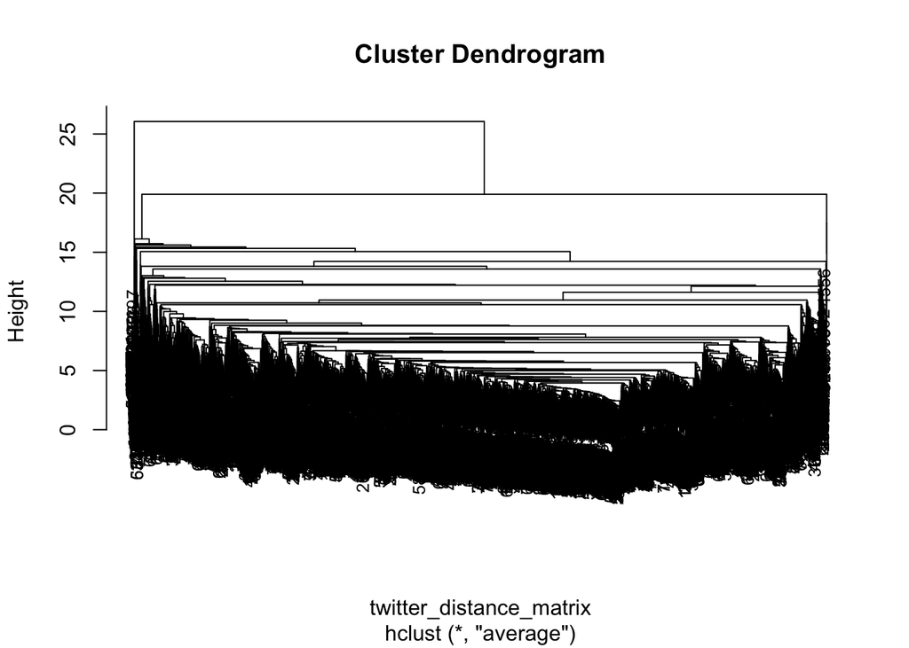

```r
set.seed(11)

#center and scale data
data = data[,2:37]
data.scaled = scale(data, center=TRUE, scale=TRUE)

#distance matrix
twitter_distance_matrix = dist(data.scaled, method='euclidean')

# Now run hierarchical clustering
hier_data = hclust(twitter_distance_matrix, method='average')

# Plot the dendrogram
plot(hier_data, cex=0.8)
```

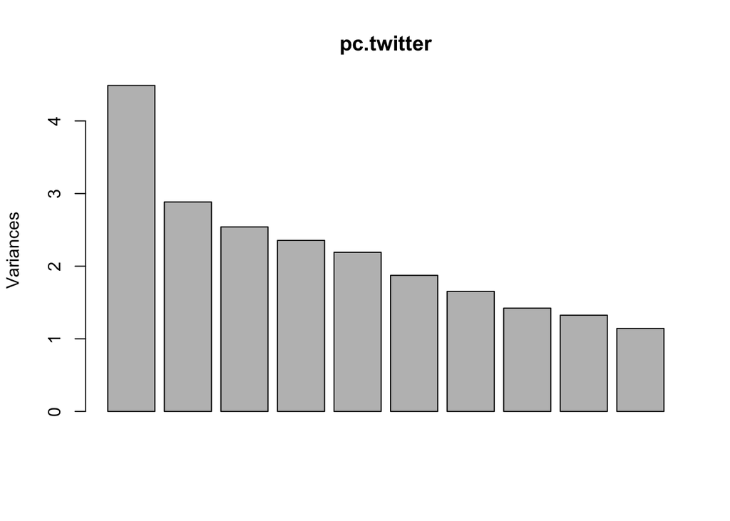

```r
#PCA
pc.twitter = prcomp(data.scaled, scale=TRUE)
plot(pc.twitter)
```

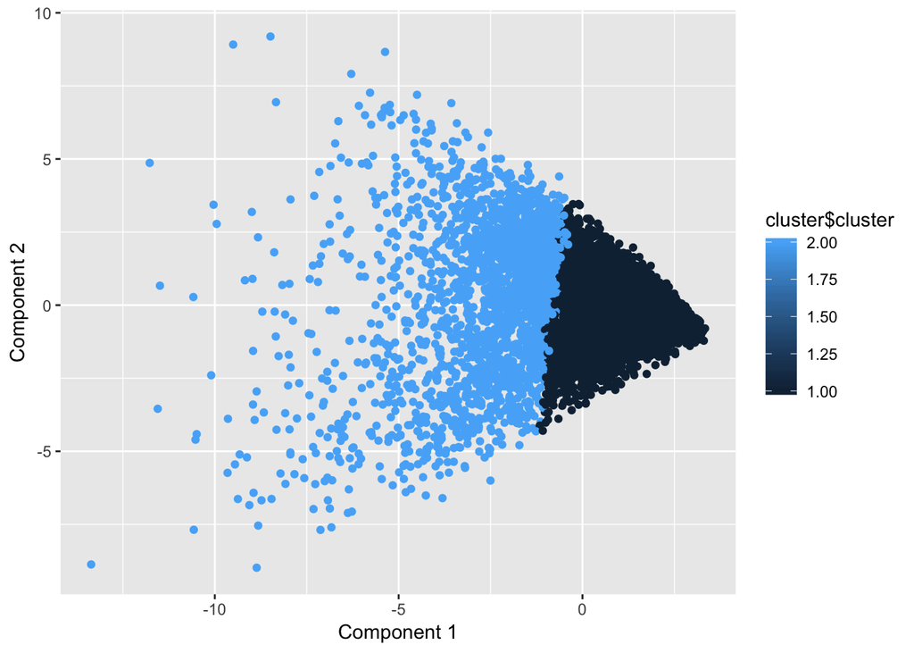

```r
loadings = pc.twitter$rotation
scores = pc.twitter$x

#kmeans cluster for segmentation of PCA plot
#2 clusters
set.seed(11)
cluster = kmeans(data.scaled, centers = 2, n=50)
qplot(scores[,1], scores[,2], color=cluster$cluster, xlab='Component 1', ylab='Component 2')
```

```r
cluster$centers
```

```
##      chatter current_events     travel photo_sharing uncategorized
## 1 -0.1497640     -0.0999871 -0.1251155    -0.2178941    -0.1101297
## 2  0.3610277      0.2410334  0.3016090     0.5252653     0.2654835
##      tv_film sports_fandom   politics       food     family
## 1 -0.1291588    -0.2725628 -0.1274090 -0.3014069 -0.2511455
## 2  0.3113561     0.6570520  0.3071378  0.7265849  0.6054227
##   home_and_garden      music       news online_gaming   shopping
## 1      -0.1290679 -0.1549627 -0.1212477    -0.1017504 -0.1599838
## 2       0.3111368  0.3735600  0.2922852     0.2452840  0.3856642
##   health_nutrition college_uni sports_playing    cooking        eco
## 1       -0.1476805  -0.1332804     -0.1657637 -0.2286508 -0.1590573
## 2        0.3560053   0.3212917      0.3995973  0.5511958  0.3834307
##    computers   business   outdoors     crafts automotive        art
## 1 -0.1550801 -0.1513739 -0.1699683 -0.2135625 -0.1273424 -0.1326175
## 2  0.3738431  0.3649086  0.4097331  0.5148234  0.3069772  0.3196937
##     religion     beauty  parenting     dating     school personal_fitness
## 1 -0.2892439 -0.2443171 -0.2869896 -0.1221821 -0.2880527       -0.1634500
## 2  0.6972643  0.5889618  0.6918299  0.2945378  0.6943926        0.3940198
##      fashion small_business        spam       adult
## 1 -0.2295206     -0.1416291 -0.01303196 -0.02661869
## 2  0.5532926      0.3414175  0.03141542  0.06416821
```

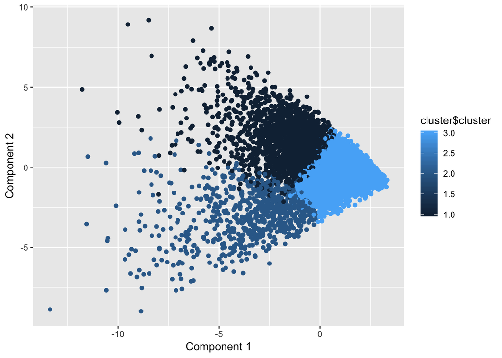

```r
#3 clusters
set.seed(11)
cluster = kmeans(data.scaled, centers = 3, n=50)
qplot(scores[,1], scores[,2], color=cluster$cluster, xlab='Component 1', ylab='Component 2')
```

```r
cluster$centers
```

```
##      chatter current_events      travel photo_sharing uncategorized
## 1  0.5565214      0.2527518  0.35068802    0.73831357    0.38818842
## 2 -0.0919489      0.1382864 -0.02094705   -0.07611764   -0.08317875
## 3 -0.2279095     -0.1330528 -0.14968603   -0.30988447   -0.15584823
##       tv_film sports_fandom    politics        food      family
## 1  0.36223903    -0.1048489  0.37877561  0.07030899  0.06475785
## 2 -0.01700495     1.9833885 -0.09603981  1.79056159  1.42058933
## 3 -0.15537651    -0.2796817 -0.14962782 -0.32452033 -0.26138618
##   home_and_garden       music         news online_gaming    shopping
## 1       0.2838196  0.42517845  0.297366176    0.24333730  0.57234449
## 2       0.1970453  0.04103381 -0.002397462    0.02452952 -0.01136432
## 3      -0.1562601 -0.19238200 -0.129447630   -0.11027519 -0.24804189
##   health_nutrition college_uni sports_playing     cooking        eco
## 1       0.50497329  0.35040291      0.3837048  0.70200125  0.4076002
## 2      -0.08707445 -0.03331184      0.1212156 -0.08247293  0.1833887
## 3      -0.20620155 -0.14753255     -0.1874304 -0.29298630 -0.2080663
##    computers   business    outdoors     crafts automotive         art
## 1  0.3626005  0.3788945  0.48618156  0.2966045  0.2668469  0.32071285
## 2  0.1506281  0.1287350 -0.02189469  0.6729960  0.1770790  0.09140192
## 3 -0.1830420 -0.1865640 -0.20869201 -0.2399432 -0.1455728 -0.15503359
##     religion     beauty   parenting      dating      school
## 1 -0.1336267  0.5253696 -0.08068717  0.35794211  0.09529207
## 2  2.2000711  0.2938062  2.05368962 -0.02317491  1.60783041
## 3 -0.3026726 -0.2776076 -0.30176763 -0.15248786 -0.30544373
##   personal_fitness     fashion small_business         spam         adult
## 1       0.52454361  0.63401423     0.37763114  0.056338678  0.0643400096
## 2      -0.03002355  0.01879561     0.08657414 -0.003389674  0.0007604057
## 3      -0.22410839 -0.27991825    -0.17909400 -0.024043319 -0.0282179993
```

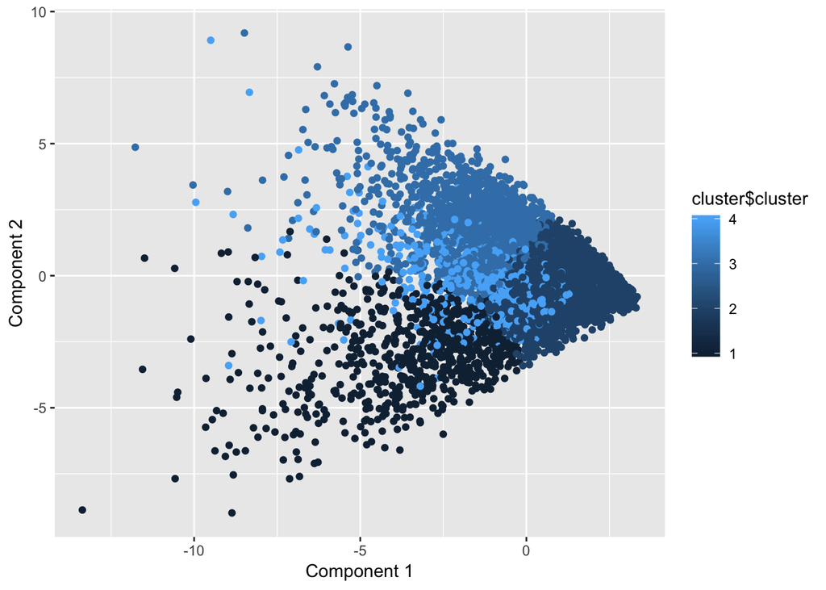

```r
#4 clusters
set.seed(11)
cluster = kmeans(data.scaled, centers = 4, n=50)
qplot(scores[,1], scores[,2], color=cluster$cluster, xlab='Component 1', ylab='Component 2')
```

```r
cluster$centers
```

```
##        chatter current_events      travel photo_sharing uncategorized
## 1 -0.081998119      0.1209128 -0.10612678   -0.05440228   -0.07148329
## 2 -0.207297642     -0.1214071 -0.22867373   -0.29754649   -0.15019740
## 3  0.551426132      0.2122847 -0.07449027    0.80179380    0.41762259
## 4  0.001701624      0.1029249  1.76871362   -0.09203676   -0.03214014
##       tv_film sports_fandom   politics        food      family
## 1 -0.01097394     2.0214691 -0.1987502  1.80894586  1.46187536
## 2 -0.15014700    -0.3011154 -0.2751948 -0.33736995 -0.27123736
## 3  0.36249338    -0.1772778 -0.1563380  0.06943008  0.04107103
## 4  0.04374918     0.2073217  2.3758806  0.03564873  0.05836763
##   home_and_garden       music        news online_gaming     shopping
## 1       0.1734206  0.04591515 -0.07924156    0.02355572  0.008613081
## 2      -0.1554968 -0.19507705 -0.24491051   -0.10131763 -0.226266181
## 3       0.2678907  0.48539668 -0.11266249    0.25331949  0.580467402
## 4       0.1221193 -0.04486926  1.94155589   -0.02611189 -0.048786761
```

[output cut: 20 more lines]

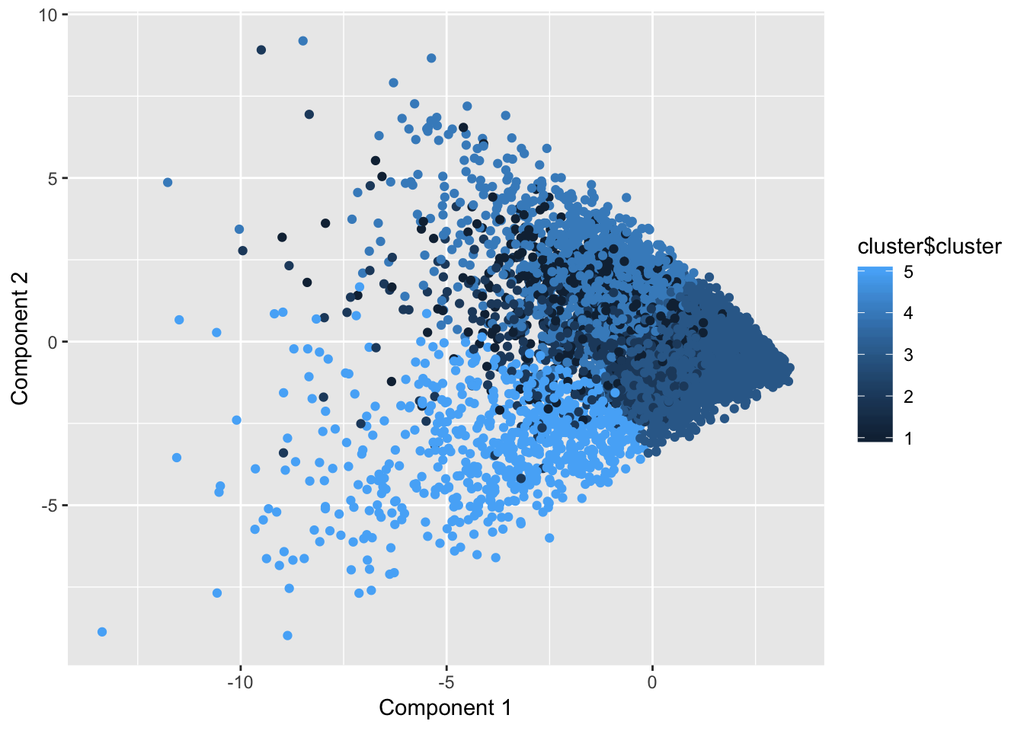

```r
#5 clusters
set.seed(11)
cluster = kmeans(data.scaled, centers = 5, n=50)
qplot(scores[,1], scores[,2], color=cluster$cluster, xlab='Component 1', ylab='Component 2')
```

```r
cluster$centers
```

```
##       chatter current_events      travel photo_sharing uncategorized
## 1 -0.08693446    -0.01073276 -0.15487410   -0.05184131    0.14824172
## 2 -0.00641441     0.10280954  1.84812814   -0.10919601   -0.04577894
## 3 -0.21208342    -0.12931452 -0.23425089   -0.31370653   -0.16642873
## 4  0.71904694     0.27525001 -0.03719217    1.03137406    0.45687479
## 5 -0.08580333     0.11668616 -0.09868363   -0.06461891   -0.07741713
##        tv_film sports_fandom   politics        food      family
## 1 -0.104043474    -0.1924418 -0.1809244  0.43514619 -0.07567456
## 2  0.030509586     0.1906405  2.4332797  0.03503888  0.04903569
## 3 -0.149302014    -0.2976276 -0.2725943 -0.36615240 -0.27111964
## 4  0.487125072    -0.1645367 -0.1316750 -0.15454924  0.04054805
## 5 -0.004897907     2.0495745 -0.1991008  1.81964863  1.49474377
##   home_and_garden       music        news online_gaming      shopping
## 1       0.1404359  0.02124261 -0.03108450   -0.06273584 -0.0061958076
## 2       0.1238786 -0.04942746  1.93197154   -0.07159622 -0.0560072470
```

[output cut: 27 more lines]

We ran clusters for multiple values of centers, and ultimately chose the 3 cluster model to be the most telling of market segments. We drew the following conclusions from the cluster centers of this model:

Cluster 1: above average instances of chatter, photo sharing, shopping, cooking, fashion, fitness, and beauty tweets Cluster 2: above average instances of crafts, sports, family, food, religion, parenting, and school tweets Cluster 3: below average in every category (not frequent tweeters)

From this analysis, we have determined two significant categories of followers that NutrientH20 could target in social media promotions. One is potentially younger females, ranging from teenagers to younger adults. One is potentially parents, who tweet about the activities of their children and other family activities.